# County Tariff Exposure: Guided Student Workbook

Ian Helfrich

2026-03-04

## How To Use This Workbook

This notebook is built for a discussion-first tutoring flow.

The goal is not to sprint to coefficients. The goal is to understand what each object means, what each design choice buys us, and what each estimate can honestly claim.

Suggested flow in session: read each section heading and short note out loud, run the chunk, then pause for the checkpoint question before moving on.

## 0) Preflight: Make Sure We Are In The Project Root

```r
if (file.exists("retaliatory-tariff.Rproj")) {
  project_root <- "."
} else if (file.exists("../retaliatory-tariff.Rproj")) {
  project_root <- ".."
} else {
  stop("Could not find retaliatory-tariff.Rproj. Open this notebook inside the project folder.")
}

setwd(project_root)
knitr::opts_knit$set(root.dir = normalizePath(getwd()))
cat("Working directory set to:", normalizePath(getwd()), "\n")
```

```
Working directory set to: /Users/ian/gemini_playground/tutoring/Jubili_RCoding/retaliatory-tariff
```

```r
core_files <- c(
  "data/data_cleaning_code/build_county_exposure.R",
  "data/data_cleaning_code/clean_tariff_retaliation.R",
  "code/overhaul_open_data_panel.R",
  "data/public/derived/county_tariff_exposure_panel_with_votes_2017_2023.csv",
  "data/public/derived/county_industry_tariff_panel_2017_2023.csv"
)

missing_core <- core_files[!file.exists(core_files)]
if (length(missing_core) > 0) {
  stop("Missing required files:\n", paste("-", missing_core, collapse = "\n"))
}

cat("Preflight check passed. Core files are present.\n")
```

```
Preflight check passed. Core files are present.
```

```r
needed <- c(
  "readr", "dplyr", "tidyr", "stringr", "ggplot2", "scales",
  "knitr", "fixest", "modelsummary", "sf", "tigris"
)

missing_pkgs <- needed[!vapply(needed, requireNamespace, quietly = TRUE, FUN.VALUE = logical(1))]
if (length(missing_pkgs) > 0) {
  stop(
    "Install missing packages first:\n",
    paste("install.packages('", missing_pkgs, "')", collapse = "\n")
  )
}

suppressPackageStartupMessages({
  library(readr)
  library(dplyr)
  library(tidyr)
  library(stringr)
  library(ggplot2)
  library(scales)
  library(knitr)
})
```

## 1) Start With Respect: What She Got Right

Her first instinct was excellent.

The skeleton of the measure was already in the Bartik/shift-share family:

$$\text{Local Exposure} \approx \text{Shock Magnitude} \times \text{Local
Reliance}$$

The upgrade is not about replacing her idea. It is about improving the geography of the shock and the scaling of intensity.

### Checkpoint

In your own words, what is the difference between replacing an idea and refining an idea?

## 2) Diagnose The Original Pipeline (Without Throwing It Away)

### 2.1 Look At The Legacy Script Inputs

```r
legacy_exports <- read_csv("data/tools/export_with_fips.csv", show_col_types = FALSE)

legacy_fips <- legacy_exports %>%
  mutate(fips_code = str_replace_all(fips_code, ";", ",")) %>%
  separate_rows(fips_code, sep = ",") %>%
  mutate(
    fips_code = str_trim(fips_code),
    county_fips = str_extract(fips_code, "[0-9]{5}")
  )

legacy_summary <- legacy_fips %>%
  summarise(
    raw_rows = n(),
    unique_districts = n_distinct(District),
    unique_counties = n_distinct(county_fips, na.rm = TRUE),
    share_missing_fips = mean(is.na(county_fips))
  )

kable(legacy_summary, digits = 3)
```

| raw_rows | unique_districts | unique_counties | share_missing_fips |
| --- | --- | --- | --- |
| 100259 | 46 | 53 | 0.035 |

### 2.2 Why This Matters

If local assignment is based mainly on customs district geography, we risk confusing where goods exit with where goods are produced.

That is the core “Laredo problem” in one line.

### Checkpoint

Why can a port-heavy county look artificially exposed in this setup?

## 3) Load The Upgraded County Panel

```r
panel <- read_csv(
  "data/public/derived/county_tariff_exposure_panel_with_votes_2017_2023.csv",
  show_col_types = FALSE
) %>%
  mutate(
    county_fips = str_pad(as.character(county_fips), 5, pad = "0"),
    year = as.integer(year)
  )

panel %>%
  summarise(
    rows = n(),
    years = n_distinct(year),
    counties = n_distinct(county_fips),
    min_year = min(year, na.rm = TRUE),
    max_year = max(year, na.rm = TRUE)
  ) %>%
  kable()
```

| rows | years | counties | min_year | max_year |
| --- | --- | --- | --- | --- |
| 22659 | 7 | 3253 | 2017 | 2023 |

```r
panel %>%
  group_by(year) %>%
  summarise(counties = n_distinct(county_fips), .groups = "drop") %>%
  kable()
```

| year | counties |
| --- | --- |
| 2017 | 3235 |
| 2018 | 3235 |
| 2019 | 3237 |
| 2020 | 3238 |
| 2021 | 3238 |
| 2022 | 3239 |
| 2023 | 3237 |

### 3.1 One Real Data Cleaning Note: State Name Gaps

```r
state_gap <- panel %>%
  mutate(statefp = str_sub(county_fips, 1, 2)) %>%
  summarise(
    missing_state_name = sum(is.na(state_name) | state_name == ""),
    share_missing = mean(is.na(state_name) | state_name == "")
  )

kable(state_gap, digits = 3)
```

| missing_state_name | share_missing |
| --- | --- |
| 943 | 0.042 |

```r
panel %>%
  mutate(statefp = str_sub(county_fips, 1, 2)) %>%
  filter(is.na(state_name) | state_name == "") %>%
  count(statefp, sort = TRUE) %>%
  kable()
```

| statefp | n |
| --- | --- |
| 72 | 546 |
| 02 | 184 |
| 66 | 117 |
| 09 | 40 |
| 69 | 21 |
| 78 | 21 |
| 60 | 14 |

This is worth teaching directly: a strong design still needs messy-data honesty.

## 4) Reconstruct The Exposure Formula From Components

Now we open the county-industry panel and verify the math at the row level.

```r
components <- read_csv(
  "data/public/derived/county_industry_tariff_panel_2017_2023.csv",
  show_col_types = FALSE
) %>%
  mutate(
    county_fips = str_pad(as.character(county_fips), 5, pad = "0"),
    year = as.integer(year)
  )

components %>%
  select(county_fips, county_name, year, naics2c, emp_share, export_value_usd,
         tariff_rate_mean, county_tariff_component_mean) %>%
  slice_head(n = 5) %>%
  kable(digits = 4)
```

| county_fips | county_name | year | naics2c | emp_share | export_value_usd | tariff_rate_mean | county_tariff_component_mean |
| --- | --- | --- | --- | --- | --- | --- | --- |
| 01001 | Autauga County, Alabama | 2017 | 11 | 0.0084 | 79230432234 | 0.2589 | 11627099 |
| 01003 | Baldwin County, Alabama | 2017 | 11 | 0.0002 | 79230432234 | 0.2589 | 1250226 |
| 01005 | Barbour County, Alabama | 2017 | 11 | 0.0218 | 79230432234 | 0.2589 | 18628363 |
| 01007 | Bibb County, Alabama | 2017 | 11 | 0.0212 | 79230432234 | 0.2589 | 9251670 |
| 01009 | Blount County, Alabama | 2017 | 11 | 0.0011 | 79230432234 | 0.2589 | 875158 |

### 4.1 Example: Hoonah-Angoon Census Area

```r
focus_county <- components %>%
  filter(str_detect(county_name, "Hoonah-Angoon")) %>%
  distinct(county_fips, county_name) %>%
  slice(1)

focus_fips <- focus_county$county_fips[[1]]
focus_name <- focus_county$county_name[[1]]
focus_year <- max(panel$year, na.rm = TRUE)

cat("Focus county:", focus_name, "| FIPS:", focus_fips, "| Year:", focus_year, "\n")
```

```
Focus county: Hoonah-Angoon Census Area, Alaska | FIPS: 02105 | Year: 2023
```

```r
focus_components <- components %>%
  filter(county_fips == focus_fips, year == focus_year) %>%
  mutate(
    reconstructed_component = emp_share * export_value_usd * tariff_rate_mean
  ) %>%
  select(naics2c, emp_share, export_value_usd, tariff_rate_mean,
         county_tariff_component_mean, reconstructed_component) %>%
  arrange(desc(reconstructed_component))

focus_components %>%
  slice_head(n = 12) %>%
  kable(digits = 5)
```

| naics2c | emp_share | export_value_usd | tariff_rate_mean | county_tariff_component_mean | reconstructed_component |
| --- | --- | --- | --- | --- | --- |
| 22 | 0.03361 | 0 | 0 | 0 | 0 |
| 23 | 0.05602 | 0 | 0 | 0 | 0 |
| 44-45 | 0.22409 | 0 | 0 | 0 | 0 |
| 48-49 | 0.15966 | 0 | 0 | 0 | 0 |
| 53 | 0.00840 | 0 | 0 | 0 | 0 |
| 62 | 0.15126 | 0 | 0 | 0 | 0 |
| 71 | 0.15966 | 0 | 0 | 0 | 0 |
| 72 | 0.08123 | 0 | 0 | 0 | 0 |

```r
reconstructed <- components %>%
  group_by(county_fips, year) %>%
  summarise(reconstructed_exposure = sum(county_tariff_component_mean, na.rm = TRUE), .groups = "drop")

comparison <- panel %>%
  select(county_fips, year, county_tariff_exposure_mean) %>%
  inner_join(reconstructed, by = c("county_fips", "year")) %>%
  mutate(abs_diff = abs(county_tariff_exposure_mean - reconstructed_exposure))

comparison %>%
  summarise(
    max_abs_diff = max(abs_diff, na.rm = TRUE),
    median_abs_diff = median(abs_diff, na.rm = TRUE)
  ) %>%
  kable(digits = 6)
```

| max_abs_diff | median_abs_diff |
| --- | --- |
| 1e-06 | 0 |

### Checkpoint

Why is this reconstruction test one of the most important trust checks in the whole project?

## 5) NAICS Problem Scanner (Teaching + Debugging)

```r
emp_share_panel <- read_csv(
  "data/public/derived/county_industry_emp_share_2017_2023.csv",
  show_col_types = FALSE
) %>%
  mutate(
    county_fips = str_pad(as.character(county_fips), 5, pad = "0"),
    naics2c = as.character(naics2c),
    valid_naics = str_detect(naics2c, "^(00|[0-9]{2}|31-33|44-45|48-49|99)$"),
    emp = as.numeric(emp),
    emp_share = as.numeric(emp_share)
  )

naics_issues <- emp_share_panel %>%
  mutate(
    issue_type = case_when(
      !valid_naics ~ "bad_naics_format",
      is.na(emp) ~ "missing_emp",
      is.na(emp_share) ~ "missing_emp_share",
      !is.finite(emp_share) ~ "nonfinite_emp_share",
      TRUE ~ "ok"
    )
  ) %>%
  filter(issue_type != "ok") %>%
  count(year, issue_type, naics2c, sort = TRUE, name = "rows")

naics_issues %>% slice_head(n = 25) %>% kable()
```

| year | issue_type | naics2c | rows |
| --- | --- | --- | --- |
| 2017 | missing_emp_share | 21 | 1 |
| 2017 | missing_emp_share | 44-45 | 1 |
| 2017 | missing_emp_share | 48-49 | 1 |
| 2017 | missing_emp_share | 56 | 1 |
| 2017 | missing_emp_share | 62 | 1 |
| 2017 | missing_emp_share | 72 | 1 |

```r
dir.create("output/analysis/tables", recursive = TRUE, showWarnings = FALSE)
write_csv(naics_issues, "output/analysis/tables/naics_problem_entries_guided.csv")
cat("Wrote: output/analysis/tables/naics_problem_entries_guided.csv\n")
```

```
Wrote: output/analysis/tables/naics_problem_entries_guided.csv
```

## 6) Exposure Levels vs Exposure Intensity

This is the “Los Angeles problem” checkpoint: level and per-worker exposure should both be inspected.

```r
latest_year <- max(panel$year, na.rm = TRUE)
latest <- panel %>% filter(year == latest_year)

level_top <- latest %>%
  arrange(desc(county_tariff_exposure_mean)) %>%
  select(county_name, county_fips, county_tariff_exposure_mean,
         county_tariff_exposure_per_worker, county_emp_total) %>%
  slice_head(n = 15)

intensity_top <- latest %>%
  arrange(desc(county_tariff_exposure_per_worker)) %>%
  select(county_name, county_fips, county_tariff_exposure_mean,
         county_tariff_exposure_per_worker, county_emp_total) %>%
  slice_head(n = 15)

cat("Top 15 by level\n")
```

```
Top 15 by level
```

```r
kable(level_top, digits = 3)
```

| county_name | county_fips | county_tariff_exposure_mean | county_tariff_exposure_per_worker | county_emp_total |
| --- | --- | --- | --- | --- |
| Los Angeles County, California | 06037 | 9015205583 | 2260.733 | 3987736 |
| Harris County, Texas | 48201 | 7324700221 | 3356.622 | 2182164 |
| Cook County, Illinois | 17031 | 5270854463 | 2114.832 | 2492328 |
| Orange County, California | 06059 | 4322978386 | 2734.716 | 1580778 |
| Maricopa County, Arizona | 04013 | 3992995255 | 1979.684 | 2016986 |
| Dallas County, Texas | 48113 | 3630425950 | 2201.990 | 1648702 |
| San Diego County, California | 06073 | 3178246279 | 2283.681 | 1391721 |
| Tarrant County, Texas | 48439 | 2970926156 | 3367.294 | 882289 |
| Santa Clara County, California | 06085 | 2876263472 | 2455.413 | 1171397 |
| Alameda County, California | 06001 | 2742939892 | 3661.530 | 749124 |
| Wayne County, Michigan | 26163 | 2707111837 | 4067.432 | 665558 |
| King County, Washington | 53033 | 2600370709 | 1991.176 | 1305947 |
| Hennepin County, Minnesota | 27053 | 2362347734 | 2515.274 | 939201 |
| Midland County, Texas | 48329 | 2298413858 | 22775.741 | 100915 |
| Elkhart County, Indiana | 18039 | 2277778686 | 16723.902 | 136199 |

```r
cat("\nTop 15 by per-worker intensity\n")
```

```
Top 15 by per-worker intensity
```

```r
kable(intensity_top, digits = 3)
```

| county_name | county_fips | county_tariff_exposure_mean | county_tariff_exposure_per_worker | county_emp_total |
| --- | --- | --- | --- | --- |
| Marion County, Georgia | 13197 | 107952198 | 71021.18 | 1520 |
| Eureka County, Nevada | 32011 | 95953815 | 66038.41 | 1453 |
| Greenlee County, Arizona | 04011 | 256637129 | 60915.53 | 4213 |
| Slope County, North Dakota | 38087 | 3617931 | 50956.77 | 71 |
| Pershing County, Nevada | 32027 | 65662306 | 39819.47 | 1649 |
| Teton County, Montana | 30099 | 56804863 | 38987.55 | 1457 |
| Crane County, Texas | 48103 | 39482635 | 37602.51 | 1050 |
| Shackelford County, Texas | 48417 | 39446147 | 37003.89 | 1066 |
| Stillwater County, Montana | 30095 | 106209787 | 35157.16 | 3021 |
| Dewey County, Oklahoma | 40043 | 53871700 | 34666.47 | 1554 |
| White Pine County, Nevada | 32033 | 102369220 | 34642.71 | 2955 |
| Dunn County, North Dakota | 38025 | 88031179 | 33689.70 | 2613 |
| Southeast Fairbanks Census Area, Alaska | 02240 | 57580490 | 33130.32 | 1738 |
| Boone County, West Virginia | 54005 | 142698989 | 32879.95 | 4340 |
| Reagan County, Texas | 48383 | 46561195 | 32401.67 | 1437 |

### Checkpoint

Which counties jump in rank once we normalize by employment, and why?

## 7) Visual Diagnostics In R (Static Maps)

```r
latest_map <- latest %>%
  transmute(
    GEOID = county_fips,
    county_name,
    exposure = county_tariff_exposure_mean,
    exposure_per_worker = county_tariff_exposure_per_worker,
    swingness_20
  )
```

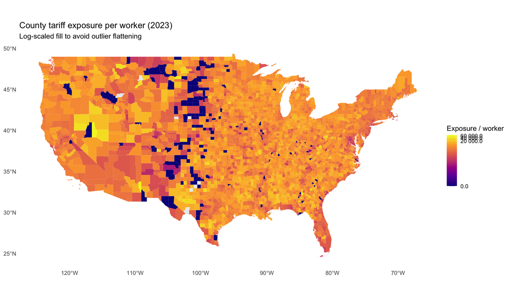

```r
options(tigris_use_cache = TRUE)

counties_sf <- tigris::counties(cb = TRUE, year = 2023, class = "sf") %>%
  sf::st_as_sf() %>%
  select(GEOID, geometry)

map_df <- counties_sf %>%
  left_join(latest_map, by = "GEOID") %>%
  filter(!str_sub(GEOID, 1, 2) %in% c("02", "15", "60", "66", "69", "72", "78"))

p_map <- ggplot(map_df) +
  geom_sf(aes(fill = exposure_per_worker), color = NA) +
  scale_fill_viridis_c(option = "C", trans = "log1p", na.value = "grey92",
                       labels = label_number(accuracy = 0.1)) +
  labs(
    title = paste0("County tariff exposure per worker (", latest_year, ")"),
    subtitle = "Log-scaled fill to avoid outlier flattening",
    fill = "Exposure / worker"
  ) +
  theme_minimal(base_size = 12) +
  theme(panel.grid = element_blank())

p_map
```

## 8) Regression Ladder (HC1, FE, Clustered)

```r
suppressPackageStartupMessages({
  library(fixest)
  library(modelsummary)
})

reg_df <- panel %>%
  mutate(
    y = log1p(county_tariff_exposure_mean),
    state_name = as.character(state_name)
  ) %>%
  filter(
    is.finite(y),
    !is.na(gop_share_20),
    !is.na(swingness_20),
    !is.na(tariffed_emp_share)
  )

m1 <- feols(y ~ gop_share_20 + swingness_20 + tariffed_emp_share,
            data = reg_df,
            vcov = "hetero")

m2 <- feols(y ~ gop_share_20 + swingness_20 + tariffed_emp_share | state_name,
            data = reg_df %>% filter(!is.na(state_name), state_name != ""),
            vcov = "hetero")

m3 <- feols(y ~ gop_share_20 + swingness_20 + tariffed_emp_share | state_name,
            data = reg_df %>% filter(!is.na(state_name), state_name != ""),
            vcov = ~state_name)

modelsummary(
  list(
    "M1: HC1" = m1,
    "M2: +State FE (HC1)" = m2,
    "M3: +State FE (Clustered)" = m3
  ),
  stars = FALSE,
  fmt = 3,
  output = "markdown"
)
```

|  | M1: HC1 | M2: +State FE (HC1) | M3: +State FE (Clustered) |
| --- | --- | --- | --- |
| (Intercept) | 15.528 |  |  |
|  | (0.253) |  |  |
| gop_share_20 | -5.655 | -5.152 | -5.152 |
|  | (0.255) | (0.267) | (1.171) |
| swingness_20 | 3.312 | 3.152 | 3.152 |
|  | (0.177) | (0.178) | (0.711) |
| tariffed_emp_share | 14.952 | 14.190 | 14.190 |
|  | (0.277) | (0.274) | (1.737) |
| Num.Obs. | 21717 | 21677 | 21677 |
| R2 | 0.292 | 0.365 | 0.365 |
| R2 Adj. | 0.292 | 0.363 | 0.363 |
| R2 Within |  | 0.236 | 0.236 |
| R2 Within Adj. |  | 0.236 | 0.236 |
| AIC | 115733.4 | 113281.4 | 113281.4 |
| BIC | 115765.3 | 113696.6 | 113696.6 |
| RMSE | 3.47 | 3.29 | 3.29 |
| Std.Errors | Heteroskedasticity-robust | Heteroskedasticity-robust | by: state_name |
| FE: state_name |  | X | X |

### Checkpoint

Which coefficient is most stable across M1, M2, and M3? Which one is most sensitive?

## 9) Interpretation Drill (Write Like A Researcher)

Use this structure when she writes findings:

1. **What changed in the model?** (specification and SE type)
2. **What stayed stable?** (sign and rough magnitude)
3. **What became less certain?** (wider intervals, clustering impact)
4. **What can we claim?** (associational vs causal discipline)

Write 3-5 sentences now using the last table.

## 10) Optional Extension: Campaign Finance Layer

```r
# Run this first if needed:
# source("code/add_campaign_finance_county_measures.R")

finance_panel <- read_csv(
  "data/public/derived/county_tariff_panel_with_campaign_finance.csv",
  show_col_types = FALSE
)

finance_panel %>%
  select(year, county_fips, donations_total, spending_total,
         donations_per_worker, spending_per_worker) %>%
  slice_head(n = 10)
```

[output not shown]

## 11) Teaching Exit Ticket

Before ending the session, ask her to answer these out loud:

1. What exactly is the shift in this project?
2. What exactly is the share in this project?
3. Why can customs-based geography mislead local exposure measurement?
4. Why do we report both level and per-worker exposure?
5. Why does clustered inference matter in county data?

If she can answer those clearly, the project has moved from coding exercise to research design.

## 12) Rebuild Commands (If You Need To Refresh Everything)

```r
source("setup_project.R")
source("code/overhaul_open_data_panel.R")
source("code/validate_core_outputs.R")
source("code/build_analysis_outputs.R")
source("code/build_site_data.R")
source("code/build_bivariate_maps.R")
source("code/build_fixest_models.R")
```